# McDonald's Nutrition Facts Project

## Contents

### Import libraries

```python
import pandas as pd
import numpy as np
import seaborn as sns
import matplotlib.pyplot as plt
%matplotlib inline
plt.style.use('fivethirtyeight')
import warnings
warnings.filterwarnings('ignore')
```

### McDonald's Nutrition Facts EDA

###### Brief Info on the dataset

- This dataset provides a nutrition analysis of every menu item on the US McDonald's menu, including breakfast, beef burgers etc
- From the data we can analyze -
  - How much calories the average McDonald's value meal contains?
  - How much beverages, like soda or coffee, contribute to the overall caloric intake?
  - If ordering grilled chicken instead of crispy increases a sandwich's nutritional value?
  - If ordering egg whites instead of whole eggs increases nutritional value?
  - The least number of items could you order from the menu to meet one day's nutritional requirements?
  - And More..

### Data Cleaning

#### Reading and Viewing csv file

```python
pd.set_option('display.max_columns', None)# set the display option to show all columns
mac = pd.read_csv('menu.csv')
```

```python
# outputs first 5 entries of dataset

mac.head()
```

|  | Category | Item | Serving Size | Calories | Calories from Fat | Total Fat | Total Fat (% Daily Value) | Saturated Fat | Saturated Fat (% Daily Value) | Trans Fat | Cholesterol | Cholesterol (% Daily Value) | Sodium | Sodium (% Daily Value) | Carbohydrates | Carbohydrates (% Daily Value) | Dietary Fiber | Dietary Fiber (% Daily Value) | Sugars | Protein | Vitamin A (% Daily Value) | Vitamin C (% Daily Value) | Calcium (% Daily Value) | Iron (% Daily Value) |
| --- | --- | --- | --- | --- | --- | --- | --- | --- | --- | --- | --- | --- | --- | --- | --- | --- | --- | --- | --- | --- | --- | --- | --- | --- |
| 0 | Breakfast | Egg McMuffin | 4.8 oz (136 g) | 300 | 120 | 13.0 | 20 | 5.0 | 25 | 0.0 | 260 | 87 | 750 | 31 | 31 | 10 | 4 | 17 | 3 | 17 | 10 | 0 | 25 | 15 |
| 1 | Breakfast | Egg White Delight | 4.8 oz (135 g) | 250 | 70 | 8.0 | 12 | 3.0 | 15 | 0.0 | 25 | 8 | 770 | 32 | 30 | 10 | 4 | 17 | 3 | 18 | 6 | 0 | 25 | 8 |
| 2 | Breakfast | Sausage McMuffin | 3.9 oz (111 g) | 370 | 200 | 23.0 | 35 | 8.0 | 42 | 0.0 | 45 | 15 | 780 | 33 | 29 | 10 | 4 | 17 | 2 | 14 | 8 | 0 | 25 | 10 |
| 3 | Breakfast | Sausage McMuffin with Egg | 5.7 oz (161 g) | 450 | 250 | 28.0 | 43 | 10.0 | 52 | 0.0 | 285 | 95 | 860 | 36 | 30 | 10 | 4 | 17 | 2 | 21 | 15 | 0 | 30 | 15 |
| 4 | Breakfast | Sausage McMuffin with Egg Whites | 5.7 oz (161 g) | 400 | 210 | 23.0 | 35 | 8.0 | 42 | 0.0 | 50 | 16 | 880 | 37 | 30 | 10 | 4 | 17 | 2 | 21 | 6 | 0 | 25 | 10 |

#### Checking the info and size of dataset

```python
# Brings out (rows, columns) of dataset

mac.shape
```

```
(260, 24)
```

- We have 260 rows and 24 columns

```python
# Gives brief information about the dataset

mac.info()
```

```
<class 'pandas.core.frame.DataFrame'>
RangeIndex: 260 entries, 0 to 259
Data columns (total 24 columns):
 #   Column                         Non-Null Count  Dtype
---  ------                         --------------  -----
 0   Category                       260 non-null    object
 1   Item                           260 non-null    object
 2   Serving Size                   260 non-null    object
 3   Calories                       260 non-null    int64
 4   Calories from Fat              260 non-null    int64
 5   Total Fat                      260 non-null    float64
 6   Total Fat (% Daily Value)      260 non-null    int64
 7   Saturated Fat                  260 non-null    float64
 8   Saturated Fat (% Daily Value)  260 non-null    int64
 9   Trans Fat                      260 non-null    float64
```

[output cut: 16 more lines]

- From the info we observe:
  - The datatypes are ok as is it is.
  - There are no null values.

#### Check the Statistical summary for numerical columns

```python
# Gives statistical summary of all numerical columns

mac.describe()
```

|  | Calories | Calories from Fat | Total Fat | Total Fat (% Daily Value) | Saturated Fat | Saturated Fat (% Daily Value) | Trans Fat | Cholesterol | Cholesterol (% Daily Value) | Sodium | Sodium (% Daily Value) | Carbohydrates | Carbohydrates (% Daily Value) | Dietary Fiber | Dietary Fiber (% Daily Value) | Sugars | Protein | Vitamin A (% Daily Value) | Vitamin C (% Daily Value) | Calcium (% Daily Value) | Iron (% Daily Value) |
| --- | --- | --- | --- | --- | --- | --- | --- | --- | --- | --- | --- | --- | --- | --- | --- | --- | --- | --- | --- | --- | --- |
| count | 260.000000 | 260.000000 | 260.000000 | 260.000000 | 260.000000 | 260.000000 | 260.000000 | 260.000000 | 260.000000 | 260.000000 | 260.000000 | 260.000000 | 260.000000 | 260.000000 | 260.000000 | 260.000000 | 260.000000 | 260.000000 | 260.000000 | 260.000000 | 260.000000 |
| mean | 368.269231 | 127.096154 | 14.165385 | 21.815385 | 6.007692 | 29.965385 | 0.203846 | 54.942308 | 18.392308 | 495.750000 | 20.676923 | 47.346154 | 15.780769 | 1.630769 | 6.530769 | 29.423077 | 13.338462 | 13.426923 | 8.534615 | 20.973077 | 7.734615 |
| std | 240.269886 | 127.875914 | 14.205998 | 21.885199 | 5.321873 | 26.639209 | 0.429133 | 87.269257 | 29.091653 | 577.026323 | 24.034954 | 28.252232 | 9.419544 | 1.567717 | 6.307057 | 28.679797 | 11.426146 | 24.366381 | 26.345542 | 17.019953 | 8.723263 |
| min | 0.000000 | 0.000000 | 0.000000 | 0.000000 | 0.000000 | 0.000000 | 0.000000 | 0.000000 | 0.000000 | 0.000000 | 0.000000 | 0.000000 | 0.000000 | 0.000000 | 0.000000 | 0.000000 | 0.000000 | 0.000000 | 0.000000 | 0.000000 | 0.000000 |
| 25% | 210.000000 | 20.000000 | 2.375000 | 3.750000 | 1.000000 | 4.750000 | 0.000000 | 5.000000 | 2.000000 | 107.500000 | 4.750000 | 30.000000 | 10.000000 | 0.000000 | 0.000000 | 5.750000 | 4.000000 | 2.000000 | 0.000000 | 6.000000 | 0.000000 |
| 50% | 340.000000 | 100.000000 | 11.000000 | 17.000000 | 5.000000 | 24.000000 | 0.000000 | 35.000000 | 11.000000 | 190.000000 | 8.000000 | 44.000000 | 15.000000 | 1.000000 | 5.000000 | 17.500000 | 12.000000 | 8.000000 | 0.000000 | 20.000000 | 4.000000 |
| 75% | 500.000000 | 200.000000 | 22.250000 | 35.000000 | 10.000000 | 48.000000 | 0.000000 | 65.000000 | 21.250000 | 865.000000 | 36.250000 | 60.000000 | 20.000000 | 3.000000 | 10.000000 | 48.000000 | 19.000000 | 15.000000 | 4.000000 | 30.000000 | 15.000000 |
| max | 1880.000000 | 1060.000000 | 118.000000 | 182.000000 | 20.000000 | 102.000000 | 2.500000 | 575.000000 | 192.000000 | 3600.000000 | 150.000000 | 141.000000 | 47.000000 | 7.000000 | 28.000000 | 128.000000 | 87.000000 | 170.000000 | 240.000000 | 70.000000 | 40.000000 |

#### Check for duplicates

```python
# checks for duplicates on all rows and sums them if any

mac.duplicated().sum()
```

```
0
```

- There are no duplicates in the dataset

#### Check for inconsistencies in text columns (Category and Item)

```python
# Output the column names

mac.columns
```

```
Index(['Category', 'Item', 'Serving Size', 'Calories', 'Calories from Fat',
       'Total Fat', 'Total Fat (% Daily Value)', 'Saturated Fat',
       'Saturated Fat (% Daily Value)', 'Trans Fat', 'Cholesterol',
       'Cholesterol (% Daily Value)', 'Sodium', 'Sodium (% Daily Value)',
       'Carbohydrates', 'Carbohydrates (% Daily Value)', 'Dietary Fiber',
       'Dietary Fiber (% Daily Value)', 'Sugars', 'Protein',
       'Vitamin A (% Daily Value)', 'Vitamin C (% Daily Value)',
       'Calcium (% Daily Value)', 'Iron (% Daily Value)'],
      dtype='object')
```

##### Check for unique values in columns

```python
# Count the number of unique values in Serving size

mac['Serving Size'].nunique()
```

```
107
```

```python
# view unique items

mac['Serving Size'].unique()
```

```
array(['4.8 oz (136 g)', '4.8 oz (135 g)', '3.9 oz (111 g)',
       '5.7 oz (161 g)', '6.5 oz (185 g)', '5.3 oz (150 g)',
       '5.8 oz (164 g)', '5.4 oz (153 g)', '5.9 oz (167 g)',
       '4.1 oz (117 g)', '4.6 oz (131 g)', '5.7 oz (163 g)',
       '6.2 oz (177 g)', '6.4 oz (181 g)', '5 oz (143 g)',
       '5.5 oz (157 g)', '7.1 oz (201 g)', '6.1 oz (174 g)',
       '6.3 oz (178 g)', '5 oz (141 g)', '7.2 oz (205 g)',
       '6.9 oz (197 g)', '8.5 oz (241 g)', '9.5 oz (269 g)',
       '10 oz (283 g)', '9.6 oz (272 g)', '10.1 oz (286 g)',
       '14.8 oz (420 g)', '15.3 oz (434 g)', '14.9 oz (423 g)',
       '15.4 oz (437 g)', '5.3 oz (151 g)', '6.8 oz (192 g)',
       '2 oz (56 g)', '4 oz (114 g)', '9.6 oz (251 g)', '7.4 oz (211 g)',
       '7.1 oz (202 g)', '8 oz (227 g)', '8.3 oz (235 g)',
       '8.6 oz (244 g)', '3.5 oz (98 g)', '4 oz (113 g)',
       '9.5 oz (270 g)', '5.2 oz (147 g)', '6.7 oz (190 g)',
       '5.6 oz (159 g)', '7.3 oz (208 g)', '7.5 oz (213 g)',
       '7 oz (200 g)', '8.8 oz (249 g)', '8.1 oz (230 g)',
       '7.6 oz (217 g)', '10 oz (284 g)', '5.6 oz (160 g)',
       '5.1 oz (143 g)', '6 oz (171 g)', '5.2 oz (148 g)',
       '11.1 oz (316 g)', '10.7 oz (302 g)', '10.9 oz (310 g)',
       '10.5 oz (297 g)', '11.1 oz (314 g)', '11.2 oz (318 g)',
       '10.7 oz (304 g)', '10.3 oz (291 g)', '2.3 oz (65 g)',
       '3.4 oz (97 g)', '5.7 oz (162 g)', '11.4 oz (323 g)',
       '22.8 oz (646 g)', '5 oz (142 g)', '7.9 oz (223 g)',
       '9 oz (255 g)', '12.3 oz (348 g)', '11.8 oz (335 g)',
       '4.6 oz (130 g)', '4.3 oz (123 g)', '4.1 oz (116 g)',
       '4.5 oz (128 g)', '4.3 oz (121 g)', '2.6 oz (75 g)',
       '5.9 oz (168 g)', '1.3 oz (38 g)', '3.1 oz (87 g)',
       '1.2 oz (34 g)', '5.2 oz (149 g)', '2.7 oz (77 g)',
       '1 cookie (33 g)', '1 oz (29 g)', '6.3 oz (179 g)',
       '6.4 oz (182 g)', '16 fl oz cup', '21 fl oz cup', '30 fl oz cup',
       '12 fl oz cup', '1 carton (236 ml)', '6 fl oz (177 ml)',
       '22 fl oz cup', '16.9 fl oz', '20 fl oz cup', '32 fl oz cup',
       '16.2 oz (460 g)', '7.3 oz (207 g)', '10.1 oz (285 g)',
       '13.4 oz (381 g)', '14.2 oz (403 g)'], dtype=object)
```

##### Making the Serving size column normal

```python
# working on the serving size column to convert everything to grams (g)

import re

# Define the regular expression pattern for extracting values in brackets
pattern = re.compile(r'\((.*?)\)')

# Apply the pattern to the 'Serving size' column and extract the values
mac['Serving Size'] = mac['Serving Size'].apply(lambda x: pattern.findall(x)[0] if pattern.findall(x) else x)

# function to extract and convert values
def serve(size):
    if ' g' in size:
        return float(size.replace(' g','')) # return value in g
    elif 'fl oz' in size:
        x, y = size.split(' fl oz')
        return round(float(float(x) * 29.574)) # 1 fl oz == 29.574 ml == 29.574g
    elif ' ml' in size:
        return float(size.replace(' ml','')) # 1ml == 1g
```

```python
# apply and rename column
mac['Serving Size'] = mac['Serving Size'].apply(serve)
mac = mac.rename(columns = {'Serving Size': 'Serving Size (g)'})
```

```python
# check for changes made

mac['Serving Size (g)'].unique()
```

```
array([136., 135., 111., 161., 185., 150., 164., 153., 167., 117., 131.,
       163., 177., 181., 143., 157., 201., 174., 178., 141., 205., 197.,
       241., 269., 283., 272., 286., 420., 434., 423., 437., 151., 192.,
        56., 114., 251., 211., 202., 227., 235., 244.,  98., 113., 270.,
       147., 190., 159., 208., 213., 200., 249., 230., 217., 284., 160.,
       171., 148., 316., 302., 310., 297., 314., 318., 304., 291.,  65.,
        97., 162., 323., 646., 142., 223., 255., 348., 335., 130., 123.,
       116., 128., 121.,  75., 168.,  38.,  87.,  34., 149.,  77.,  33.,
        29., 179., 182., 473., 621., 887., 355., 236., 651., 500., 591.,
       946., 460., 207., 285., 381., 403.])
```

```python
# Count the number of  unique values in Item

mac['Item'].nunique()
```

```
260
```

- Item column has 260 unique values which == no of rows

```python
# To ensure no inconsistency make all the text the same way

mac['Item'] = mac['Item'].str.title()
```

```python
# Check for total unique values again

mac['Item'].nunique()
```

```
260
```

- There are no inconsistencies in the text columns

## Exploratory Data Analysis (EDA)

#### View Count of items in each category

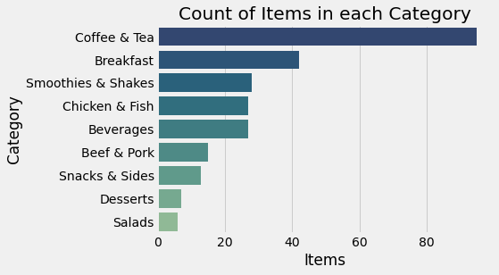

```python
# Groups and Counts the unique values in Category column
catviz = mac.Category.value_counts().reset_index()

# Visualizing our category columns
# Create a bar chart
sns.barplot(y = catviz['index'], x=catviz['Category'], palette = 'crest_r')
plt.ylabel('Category')
plt.xlabel('Items')
plt.title('Count of Items in each Category')
```

- Observations -
  - There are 9 Unique categories.
  - We have more Items on our menu for Coffee & Tea, followed by Breakfast.
  - Smoothies & Shakes, Chicken & fish and also beverages have approxiamtely equal amount of items.
  - Salads has the least items on our menu.

#### What do the Nutrients look like?

- What are the highest average amount of nutrients on our menu?

```python
# Pick the needed columns from the dataframe

avg = mac[['Calories', 'Calories from Fat', 'Total Fat', 'Saturated Fat', 'Trans Fat',
            'Cholesterol','Sodium','Carbohydrates', 'Dietary Fiber', 'Sugars', 'Protein']]


# To view the Top 5 average amount of nutrients in our menu

avg_nutrients = avg.mean().sort_values(ascending = False).reset_index()
Top5 = avg_nutrients.head()
```

```python
Top5
```

|  | index | 0 |
| --- | --- | --- |
| 0 | Sodium | 495.750000 |
| 1 | Calories | 368.269231 |
| 2 | Calories from Fat | 127.096154 |
| 3 | Cholesterol | 54.942308 |
| 4 | Carbohydrates | 47.346154 |

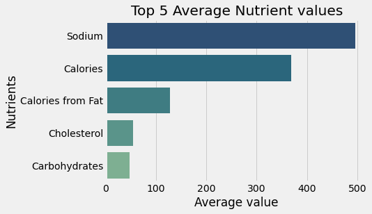

```python
## visualizing the average amount of nutrients

sns.barplot(y = 'index', x = 0, data = Top5 , palette = 'crest_r')
plt.ylabel('Nutrients')
plt.xlabel('Average value')
plt.title('Top 5 Average Nutrient values')
```

- Observations :
  - The average quantity of sodium we get from our menu is higher than the others
  - Meaning the amount of sodium you can get from the items in our menu is high
  - Our top 3 nutrients with High values are Sodium, Calories and Calories from Fat

#### What are the Food Items with Maximum Nutrient Values for Each Category?

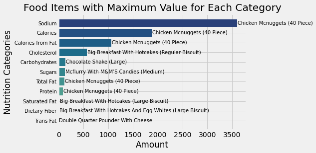

```python
# Pick the columns needed from the dataframe mac

mac2 = mac[['Category','Item','Serving Size (g)','Calories', 'Calories from Fat',
            'Total Fat', 'Saturated Fat', 'Trans Fat', 'Cholesterol','Sodium',
            'Carbohydrates', 'Dietary Fiber', 'Sugars', 'Protein']]

# Get the maximum value for each numerical column and group by 'Category','Item', 'Serving Size'
def getmax(col):
    x = mac2.groupby(['Category','Item', 'Serving Size (g)'])[col].idxmax() # gets the index where the columns are maximum

    # outputs the 'Category','Item' and 'Serving Size' where the numerical column values are max
    return mac2.loc[x, ['Category','Item', 'Serving Size (g)', col]].sort_values(by=col, ascending=False).iloc[0]
    # iloc[0] brings only the 1st row with max value

# Plot the graph
fig, ax = plt.subplots()


data = []   # create an empty variable to sort and hold the maximum values in ascending order
for col in mac2.columns[3:]:
    # Gets the maximum values for each column and puts it in max_val variable
    max_val = getmax(col)
    # put the column name, the max value, and the Item name for the max value into data variable
    data.append((col, max_val[col], max_val['Item']))

data.sort(key=lambda x: x[1])  # Sort data in ascending order of first maximum values

# Define a color palette
colors = sns.color_palette('crest', len(data))

for i, (col, val, item) in enumerate(data):
    # creates a horizontal bar chart
    ax.barh(i, val, label=col,color=colors[i])
    # adds the Item name in front of the bars with spacing of val+10 and font size of 10
    ax.text(val+10, i, item, ha='left', va='center', fontsize=10)

ax.set_yticks(range(len(data))) # Gets all values of columns to be plotted
ax.set_yticklabels([x[0] for x in data], fontsize=10) # gets the column names for the values in data to be plotted
ax.set_ylabel('Nutrition Categories') # label the y axis
ax.set_xlabel('Amount') # label the x axis
ax.set_title('Food Items with Maximum Value for Each Category') # give the graph a title


plt.show()
```

#### Observation -

```
* Chicken Mcnuggets (40 Piece) is the Food item with the highest amount of nutrients
* It is high in Sodium, Calories, Calories from fat, Total fat and Protein
```

#### What are the Food Items with Minimum Nutrient Values for Each Category

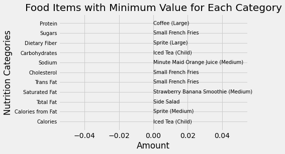

```python
# Pick the columns needed from the dataframe mac

mac2 = mac[['Category','Item','Serving Size (g)','Calories', 'Calories from Fat',
            'Total Fat', 'Saturated Fat', 'Trans Fat', 'Cholesterol','Sodium',
            'Carbohydrates', 'Dietary Fiber', 'Sugars', 'Protein']]

# Get the minimum value for each numerical column and group by 'Category','Item', 'Serving Size'
def getmax(col):
    x = mac2.groupby(['Category','Item', 'Serving Size (g)'])[col].idxmin() # gets the index where the columns are minimum

    # outputs the 'Category','Item' and 'Serving Size' where the numerical column values are min
    return mac2.loc[x, ['Category','Item', 'Serving Size (g)', col]].sort_values(by=col, ascending=True).iloc[0]
    # iloc[0] brings only the 1st row with min value

# Plot the graph
fig, ax = plt.subplots()

data = []   # create an empty variable to sort and hold the minimum values in ascending order
for col in mac2.columns[3:]:
    # Gets the minimum values for each column and puts it in max_val variable
    min_val = getmax(col)
    # put the column name, the min value, and the Item name for the min value into data variable
    data.append((col, min_val[col], min_val['Item']))

data.sort(key=lambda x: x[1])  # Sort data in ascending order of first minimum values

# Define a color palette
colors = sns.color_palette('icefire', len(data))

for i, (col, val, item) in enumerate(data):
    ax.barh(i, val, label=col,color=colors[i]) # creates a horizontal bar chart
    ax.text(val, i, item, ha='left', va='center', fontsize=10) # adds the Item name in front of the bars with font size of 10

ax.set_yticks(range(len(data))) # Gets all values of columns to be plotted
ax.set_yticklabels([x[0] for x in data], fontsize=10) # gets the column names for the values in data to be plotted
ax.set_ylabel('Nutrition Categories') # label the y axis
ax.set_xlabel('Amount') # label the x axis
ax.set_title('Food Items with Minimum Value for Each Category') # give the graph a title

plt.show()
```

- Observation -
  - Small French Fries has low Cholestrol, Trans fat and no sugar.
  - Iced Tea has no calories and no carbohydrates.

#### What are the Food Items with Maximum %Daily Nutrient Values for Each Category

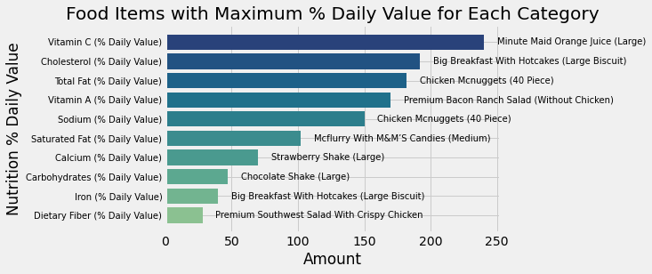

```python
# Pick the columns needed from the dataframe mac

mac3 = mac[['Category','Item','Serving Size (g)','Total Fat (% Daily Value)','Saturated Fat (% Daily Value)',
            'Cholesterol (% Daily Value)','Sodium (% Daily Value)','Carbohydrates (% Daily Value)', 'Dietary Fiber (% Daily Value)',
            'Vitamin A (% Daily Value)','Vitamin C (% Daily Value)','Calcium (% Daily Value)', 'Iron (% Daily Value)']]

# Get the maximum value for each numerical column and group by 'Category','Item', 'Serving Size'
def getmax(col):
    x = mac3.groupby(['Category','Item', 'Serving Size (g)'])[col].idxmax() # gets the index where the columns are maximum

    # outputs the 'Category','Item' and 'Serving Size' where the numerical column values are max
    return mac3.loc[x, ['Category','Item', 'Serving Size (g)', col]].sort_values(by=col, ascending=False).iloc[0]
    # iloc[0] brings only the 1st row with max value

# Plot the graph
fig, ax = plt.subplots()

data = []   # create an empty variable to sort and hold the maximum values in ascending order
for col in mac3.columns[3:]:
    # Gets the maximum values for each column and puts it in max_val variable
    max_val = getmax(col)
    # put the column name, the max value, and the Item name for the max value into data variable
    data.append((col, max_val[col], max_val['Item']))

data.sort(key=lambda x: x[1])  # Sort data in ascending order of first maximum values

# Define a color palette
colors = sns.color_palette('crest', len(data))

for i, (col, val, item) in enumerate(data):
    # creates a horizontal bar chart
    ax.barh(i, val, label=col, color=colors[i])
    # adds the Item name in front of the bars with spacing of val+10 and font size of 10
    ax.text(val+10, i, item, ha='left', va='center', fontsize=10)

ax.set_yticks(range(len(data))) # Gets all values of columns to be plotted
ax.set_yticklabels([x[0] for x in data], fontsize=10) # gets the column names for the values in data to be plotted
ax.set_ylabel('Nutrition % Daily Value') # label the y axis
ax.set_xlabel('Amount') # label the x axis
ax.set_title('Food Items with Maximum % Daily Value for Each Category') # give the graph a title

plt.show()
```

- Observation -
  - You get your % Daily Total fat (182) and Sodium (150) from Chicken Mcnuggets (40 Piece).
  - You get your % Daily Cholestrol (192) and Iron (40) from Big Breakfast with Hotcakes (Large Biscuit).
  - The least number of Food items to be ordered to reach maximum daily requirement is 8.

#### Breaking Down Nutrient Categories With High Average value (Top 3)

##### 1. Breaking Down Sodium

- What is the average level of sodium in each Category Of Food?

```python
# Get the average levels of sodium (Top 5 Categories)

# Groupby Category and get the average sodium for each category
sodlevel = mac.groupby('Category')['Sodium'].mean().round().to_frame().sort_values(by = 'Sodium',ascending = False).head().reset_index()
```

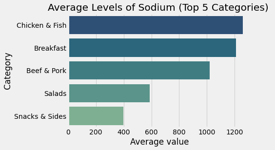

```python
# Visualizing the Top 5 Categories with the highest levels of sodium

sns.barplot(x = 'Sodium', y = 'Category', data = sodlevel, palette='crest_r')

plt.ylabel('Category') # Label y axis
plt.xlabel('Average value') # Label x axis
plt.title('Average Levels of Sodium (Top 5 Categories) ') # Label The Chart
```

- Observation
  - Chicken & Fish Category has the highest average level of sodium with a value above 1,200
  - Breakfast Category is another great medium to getting a good amount of sodium
  - Snacks and sides category are fair ways of getting sodium

##### Which Item of Food product has the highest and lowest level of Sodium and how does the serving size relate to the amount of nutrient?

#### Create Function to get max and min values for any category

```python
# Pick the needed columns from the dataframe

mac2 = mac[['Category','Item','Serving Size (g)','Calories', 'Calories from Fat', 'Total Fat', 'Saturated Fat', 'Trans Fat',
            'Cholesterol','Sodium','Carbohydrates', 'Dietary Fiber', 'Sugars', 'Protein']]

# Get the maximum value for each numerical column and group by 'Category','Item', 'Serving Size'
def getmax(col):
    x = mac2.groupby(['Category', 'Item', 'Serving Size (g)'])[col].idxmax() # gets the index where the columns are maximum

    # outputs the 'Category','Item' and 'Serving Size' where the numerical column values are max
    return mac2.loc[x, ['Category', 'Item', 'Serving Size (g)', col]].sort_values(by=col, ascending=False).head().sort_values(by=col,ascending = True).reset_index()
    # .head(5) brings out first 5 maximum values

for col in mac2.columns[3:]: # loops through and gets the max values for each column
    getmax(col) # calls the function


#-------------------------Get Minimum------------------------------------------------#


# Get the minimum value for each numerical column and group by 'Category','Item', 'Serving Size'
def getmin(col):
    x = mac2.groupby(['Category', 'Item', 'Serving Size (g)'])[col].idxmin() # gets the index where the columns are minimum

    # outputs the 'Category','Item' and 'Serving Size' where the numerical column values are max
    return mac2.loc[x, ['Category', 'Item', 'Serving Size (g)', col]].sort_values(by=col, ascending=True).head().sort_values(by=col,ascending = False).reset_index()
    # .head(5) brings out first 5 minimum values

for col in mac2.columns[3:]: # loops through and gets the min values for each column
    getmin(col) # calls the function
```

##### For Sodium

- Which Item of Food product has the highest and lowest amount of sodium and how does the serving size relate to the amount of sodium?

##### Call function to Get the max and min Sodium amount

```python
# Get the Top 5 Items with the highest level of sodium with their serving size

# Get the top 5 items where sodium is max for each category
sod_result = getmax('Sodium')

# Get the top 5 items where sodium is min for each category
sod_result1 = getmin('Sodium')
```

##### Visualize the max and min sodium amount

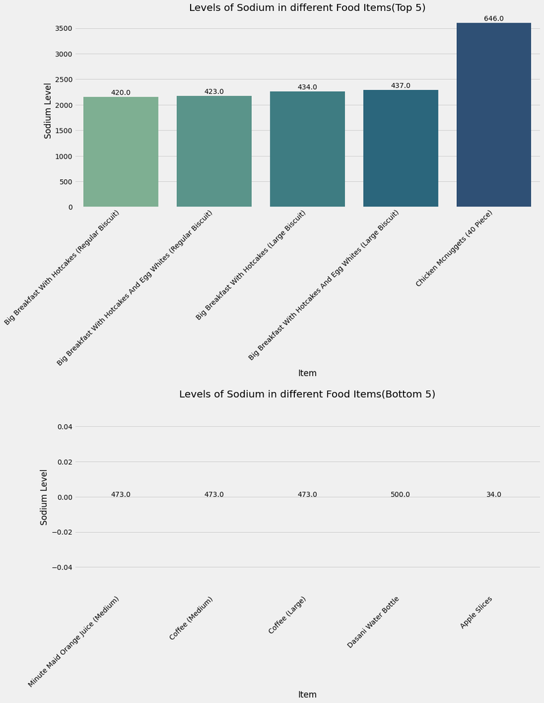

```python
# Create a barplot

# create a grid of subplots with 1 row and 2 columns
fig, axes = plt.subplots(nrows=2, ncols=1, figsize=(15, 20))

# plot the first graph in the first subplot
sns.barplot(x = 'Item', y = 'Sodium', data = sod_result, ax=axes[0], palette='crest')

# Add the serving size values on top of the bars
for i in range(len(sod_result)):
    axes[0].text(i, sod_result['Sodium'][i] + 45, f"{sod_result['Serving Size (g)'][i]}", rotation=0, ha='center')

axes[0].set_title('Levels of Sodium in different Food Items(Top 5)')
axes[0].set_xticklabels(sod_result['Item'], rotation=45, ha='right')
axes[0].set_ylabel('Sodium Level')

# --------------------------------------------------------------

# plot the second graph in the second subplot
sns.barplot(x = 'Item', y = 'Sodium', data = sod_result1, ax=axes[1])

# Add the serving size values on top of the bars
for i in range(len(sod_result1)):
    axes[1].text(i, sod_result1['Sodium'][i] + 0 , f"{sod_result1['Serving Size (g)'][i]}", rotation=0, ha='center')

axes[1].set_title('Levels of Sodium in different Food Items(Bottom 5)')
axes[1].set_xticklabels(sod_result1['Item'], rotation=45, ha='right')
axes[1].set_ylabel('Sodium Level')


# adjust the spacing between subplots and display the plot
plt.subplots_adjust(hspace=1)
```

- Observation -
  - The Top 3 Food Products with high amount of sodium are :

    ```
      * i.   Chicken Mcnuggets (40 piece) - (646g).
      * ii.  Big Breakfast with Hot cakes and Egg Whites (Large Biscuit) - (437g).
      * iii. Big Breakfast with Hot cakes (Large Biscuit) - (434g).
    ```

  - As the serving size of Food items increase, so does the level of Sodium.
  - Adding Egg whites to Food, increases the sodium amount and serving size amount.
  - The bottom 5 Food Products have no or 0 amount of sodium regardless of the serving size.

##### View low sodium Foods with sodium > 0

```python
# view low calorie Foods with calorie > 0

low_sod = mac2[mac2['Sodium'] > 0][['Category', 'Item', 'Serving Size (g)','Sodium']].sort_values(by = 'Sodium' , ascending=True).head()

# call the variable
low_sod
```

|  | Category | Item | Serving Size (g) | Sodium |
| --- | --- | --- | --- | --- |
| 112 | Beverages | Coca-Cola Classic (Large) | 887.0 | 5 |
| 135 | Beverages | Minute Maid Orange Juice (Large) | 651.0 | 5 |
| 144 | Coffee & Tea | Sweet Tea (Child) | 355.0 | 5 |
| 111 | Beverages | Coca-Cola Classic (Medium) | 621.0 | 5 |
| 140 | Coffee & Tea | Iced Tea (Child) | 355.0 | 5 |

#### 2. Breaking down Calories

- What are the average level of calories in each Category Of Food?

```python
# Get the average levels of calories (Top 5 Categories)

# Groupby Category and get the average calories for each category
callevel = mac.groupby('Category')['Calories'].mean().round().to_frame().sort_values(by = 'Calories',ascending = False).head().reset_index()
```

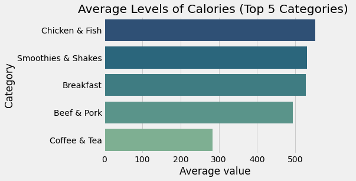

```python
# Visualizing the Top 5 Categories with the highest levels of calories

sns.barplot(x = 'Calories', y = 'Category', data = callevel, palette='crest_r')

plt.ylabel('Category') # Label y axis
plt.xlabel('Average value') # Label x axis
plt.title('Average Levels of Calories (Top 5 Categories) ') # Label The Chart
```

- Observation
  - Chicken & Fish Category has the highest average level of calories with a value above 500.
  - Smoothies & Shakes, Breakfast, Beef & Pork are great mediums to getting a good amount of calories too.
  - Coffee & Tea also contribute to getting calories.

##### For Calories

- Which Item of Food product has the highest and lowest amount calories and how does the serving size relate to the amount of calories?

##### Get the max and min calorie amount

```python
# Get the Top 5 Items with the highest level of sodium with their serving size

# Get the top 5 items where sodium is max for each category
cal_result = getmax('Calories')

# Get the top 5 items where sodium is max for each category
cal_result1 = getmin('Calories')
```

##### Visualize the max and min calorie amount

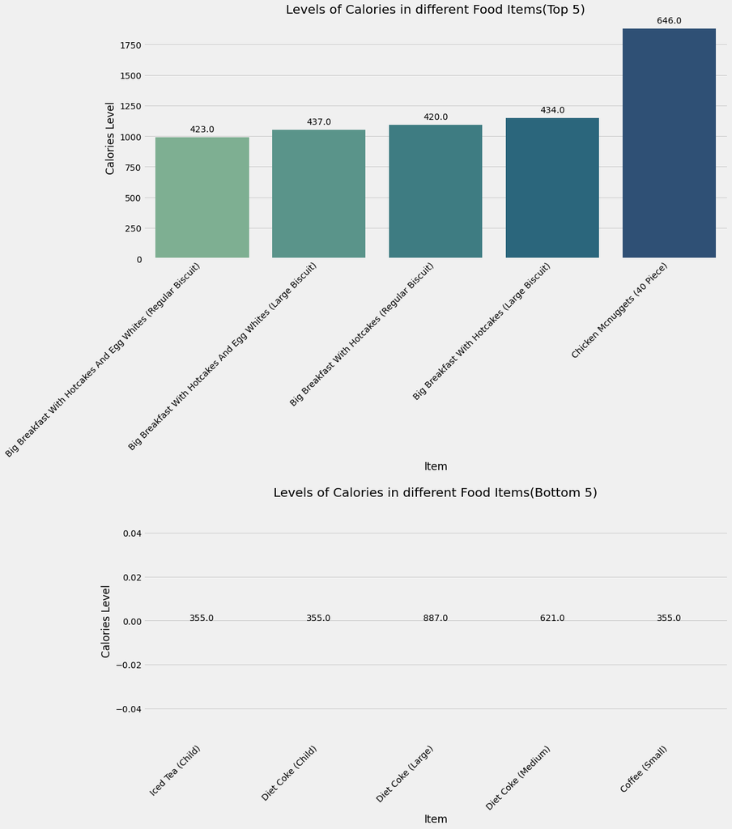

```python
# Create a barplot

# create a grid of subplots with 1 row and 2 columns
fig, axes = plt.subplots(nrows=2, ncols=1, figsize=(15, 20))

# plot the first graph in the first subplot
sns.barplot(x = 'Item', y = 'Calories', data = cal_result, ax=axes[0], palette='crest')
# Add the serving size values on top of the bars
for i in range(len(cal_result)):
    axes[0].text(i, cal_result['Calories'][i] + 45, f"{cal_result['Serving Size (g)'][i]}", rotation=0, ha='center')

axes[0].set_title('Levels of Calories in different Food Items(Top 5)')
axes[0].set_xticklabels(cal_result['Item'], rotation=45, ha='right')
axes[0].set_ylabel('Calories Level')

# --------------------------------------------------------------

# plot the second graph in the second subplot
sns.barplot(x = 'Item', y = 'Calories', data = cal_result1, ax=axes[1])

# Add the serving size values on top of the bars
for i in range(len(cal_result1)):
    axes[1].text(i, cal_result1['Calories'][i] + 0 , f"{cal_result1['Serving Size (g)'][i]}", rotation=0, ha='center')

axes[1].set_title('Levels of Calories in different Food Items(Bottom 5)')
axes[1].set_xticklabels(cal_result1['Item'], rotation=45, ha='right')
axes[1].set_ylabel('Calories Level')


# adjust the spacing between subplots and display the plot
plt.subplots_adjust(hspace=1)
```

- Observation -
  - The Top 3 Food Products with high amount of calories are :

    ```
      * i.   Chicken Mcnuggets (40 piece) - (646g)
      * ii.  Big Breakfast with Hot cakes (Large Biscuit) - (434g) - No Egg Whites.
      * iii. Big Breakfast with Hot cakes (Regular Biscuit) - (420g) - No Egg Whites.
    ```

  - As the serving size of Food items increase, so does the level of Calories but its not a regular case..
  - For Big Breakfast, the size of the Biscuit (regular or large) affects the amount of calories.
  - The bottom 5 Food Products have no or 0 amount of calories regardless of the serving size.
  - Highest Calorie Food is 1900 and lowest Calorie Food is 0.

##### View low calorie Foods with calorie > 0

```python
# view low calorie Foods with calorie > 0

low_cal = mac2[mac2['Calories'] > 0][['Category', 'Item', 'Serving Size (g)','Calories']].sort_values(by = 'Calories' , ascending=True).head()

# call the variable
low_cal
```

|  | Category | Item | Serving Size (g) | Calories |
| --- | --- | --- | --- | --- |
| 101 | Snacks & Sides | Apple Slices | 34.0 | 15 |
| 100 | Snacks & Sides | Side Salad | 87.0 | 20 |
| 106 | Desserts | Kids Ice Cream Cone | 29.0 | 45 |
| 132 | Beverages | Minute Maid 100% Apple Juice Box | 177.0 | 80 |
| 208 | Coffee & Tea | Iced Coffee With Sugar Free French Vanilla Syr... | 473.0 | 80 |

#### 3. Breaking down Cholesterol

- What is the average level of Cholesterol in each Category of Food?

```python
# Get the average levels of cholesterol (Top 5 Categories)

# Groupby Category and get the average cholestrol for each category
cholevel = mac.groupby('Category')['Cholesterol'].mean().round().to_frame().sort_values(by = 'Cholesterol',ascending = False).head().reset_index()
```

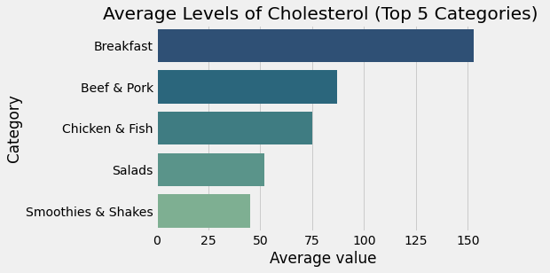

```python
# Visualizing the Top 5 Categories with the highest levels of cholesterol

sns.barplot(x = 'Cholesterol', y = 'Category', data = cholevel, palette='crest_r')

plt.ylabel('Category') # Label y axis
plt.xlabel('Average value') # Label x axis
plt.title('Average Levels of Cholesterol (Top 5 Categories) ') # Label The Chart
```

#### Observation -

```
* Breakfast Category has the highest average level of cholesterol with a value above 150.
* Beef & Pork and Chicken & Fish are Categories with a fairly good amount of cholesterol.
```

##### For Cholesterol

- Which Item of Food product has the highest and lowest amount of cholesterol and how does the serving size relate to the amount of cholesterol?

##### Get the max and min cholesterol amount

```python
# Get the Top 5 Items with the highest level of cholesterol with their serving size

# Get the top 5 items where cholesterol is max for each category
cho_result = getmax('Cholesterol')

# Get the top 5 items where cholesterol is max for each category
cho_result1 = getmin('Cholesterol')
```

##### Visualize the max and min cholesterol amount

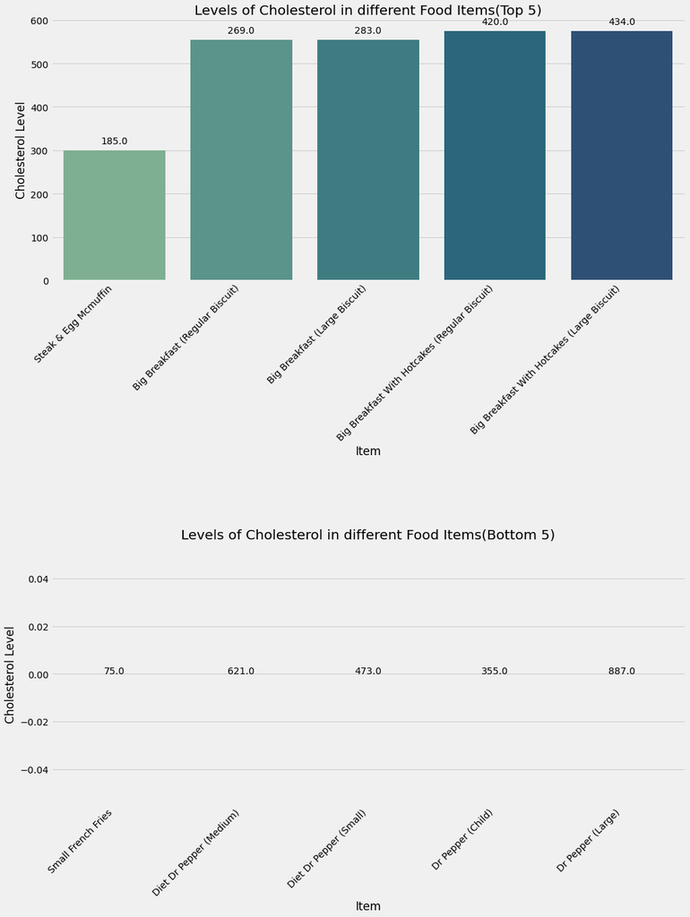

```python
# Create a barplot

# create a grid of subplots with 1 row and 2 columns
fig, axes = plt.subplots(nrows=2, ncols=1, figsize=(15, 20))

# plot the first graph in the first subplot
sns.barplot(x = 'Item', y = 'Cholesterol', data = cho_result, ax=axes[0], palette='crest')

# Add the serving size values on top of the bars
for i in range(len(cho_result)):
    axes[0].text(i, cho_result['Cholesterol'][i] + 15, f"{cho_result['Serving Size (g)'][i]}", rotation=0, ha='center')

axes[0].set_title('Levels of Cholesterol in different Food Items(Top 5)')
axes[0].set_xticklabels(cho_result['Item'], rotation=45, ha='right')
axes[0].set_ylabel('Cholesterol Level')

# --------------------------------------------------------------

# plot the second graph in the second subplot
sns.barplot(x = 'Item', y = 'Cholesterol', data = cho_result1, ax=axes[1])

# Add the serving size values on top of the bars
for i in range(len(cho_result1)):
    axes[1].text(i, cho_result1['Cholesterol'][i] + 0 , f"{cho_result1['Serving Size (g)'][i]}", rotation=0, ha='center')

axes[1].set_title('Levels of Cholesterol in different Food Items(Bottom 5)')
axes[1].set_xticklabels(cho_result1['Item'], rotation=45, ha='right')
axes[1].set_ylabel('Cholesterol Level')


# adjust the spacing between subplots and display the plot
plt.subplots_adjust(hspace=1)
```

- Observation -
  - Big Breakfast with Hotcakes(Regular and Large) both have the highest level of cholesterol.
  - Increase in serving size of Food items doesn't necessarily increase the amount of cholesterol.
  - After Big Breakfast categories, Steak & Mcmuffin is the next food item with high amount of cholesterol.
  - The bottom 5 Food Products have no or 0 amount of cholesterol regardless of the serving size.
  - Highest Cholesterol Food is 575 and lowest Calorie Food is 0.

##### View low cholesterol Foods with cholesterol > 0

```python
# view low calorie Foods with calorie > 0

low_cho = mac2[mac2['Cholesterol'] > 0][['Category', 'Item', 'Serving Size (g)','Cholesterol']].sort_values(by = 'Cholesterol' , ascending=True).head()

# call the variable
low_cho
```

|  | Category | Item | Serving Size (g) | Cholesterol |
| --- | --- | --- | --- | --- |
| 163 | Coffee & Tea | Nonfat Latte (Small) | 355.0 | 5 |
| 170 | Coffee & Tea | Nonfat Hazelnut Latte (Medium) | 473.0 | 5 |
| 175 | Coffee & Tea | Nonfat Latte With Sugar Free French Vanilla Sy... | 355.0 | 5 |
| 172 | Coffee & Tea | Nonfat French Vanilla Latte (Small) | 355.0 | 5 |
| 167 | Coffee & Tea | Nonfat Caramel Latte (Medium) | 473.0 | 5 |

### How much calories the average McDonald's value meal contains?

```python
# Get the maximum calories for each category (9)

cal_max = mac.groupby('Category')['Calories'].max().round().to_frame().sort_values(by = 'Calories',ascending = False)
```

```python
# Get the average amount of calories assuming one of each category was ordered

cal_max.mean().to_frame()
```

|  | 0 |
| --- | --- |
| Calories | 783.333333 |

- Observation - Assuming the maximum calorie item from each category was ordered. The average calorie you will gain is approximately 800

### How much beverages, like soda or coffee, contribute to the overall caloric intake?

```python
# Get the number of Items in Coffee & Tea that contribute to caloric intake

# Counts the total number of items in category for coffee & tea
ctcount = mac[mac['Category'] == 'Coffee & Tea']['Calories'].count()

# Counts the total number of items in category for coffee & tea that has calories
cal_ct = mac[mac['Category'] == 'Coffee & Tea'][mac['Calories'] > 0].value_counts().sum()

print('Out of', ctcount, 'Coffee & Tea,', cal_ct, 'contribute to Caloric intake.')
```

```
Out of 95 Coffee & Tea, 88 contribute to Caloric intake.
```

- Which Coffee and tea Item has the most amount of calories?

```python
# Pick the columns needed from the dataframe mac

mac4 = mac[['Category','Item','Serving Size (g)','Calories']]

# gets the index where the calorie is maximum
ct = mac4.groupby(['Category', 'Serving Size (g)'])['Calories'].idxmax()

# outputs the 'Category','Item' and 'Serving Size' where the numerical calorie is max for coffee & tea
item = mac4.loc[ct, ['Category','Item', 'Serving Size (g)', 'Calories']]

# sort for max values for coffee & tea, iloc[0] brings only the 1st row with max value
ct_item = item[item['Category'] == 'Coffee & Tea'].sort_values(by='Calories', ascending = False).iloc[0]

ct_item.to_frame()
```

|  | 231 |
| --- | --- |
| Category | Coffee & Tea |
| Item | Frappé Chocolate Chip (Large) |
| Serving Size (g) | 651.0 |
| Calories | 760 |

```python
# Get the number of Items in Beverages that contribute to caloric intake

# Counts the total number of items in category for Beverages
bevcount = mac[mac['Category'] == 'Beverages']['Calories'].count()

# Counts the total number of items in category for Beverages that has calories
cal_bev = mac[mac['Category'] == 'Beverages'][mac['Calories'] > 0].value_counts().sum()

print('Out of', bevcount, 'Beverages,', cal_bev, 'contribute to Caloric intake.')
```

```
Out of 27 Beverages, 18 contribute to Caloric intake.
```

- Which Beverages Item has the most amount of calories?

```python
# sort for max values for coffee & tea, iloc[0] brings only the 1st row with max value
bev_item = item[item['Category'] == 'Beverages'].sort_values(by='Calories', ascending = False).iloc[0]

bev_item.to_frame()
```

|  | 135 |
| --- | --- |
| Category | Beverages |
| Item | Minute Maid Orange Juice (Large) |
| Serving Size (g) | 651.0 |
| Calories | 280 |

### If ordering grilled chicken instead of crispy increases a sandwich's nutritional value?

###### For Grilled

```python
# Check for where category is chicken & fish and where item contains 'grilled' for Nutrients
grill = mac2[mac['Category'] == 'Chicken & Fish'][mac['Item'].str.contains('grilled', case=False)].mean().sort_values(ascending = False).reset_index()

# Check for where category is chicken & fish and where item contains 'grilled' for %Daily value
grill1 = mac3[mac['Category'] == 'Chicken & Fish'][mac['Item'].str.contains('grilled', case=False)].mean().sort_values(ascending = False).reset_index()
```

###### For Crispy

```python
# Check for where category is chicken & fish and where item contains 'crispy' for Nutrients
crispy = mac2[mac['Category'] == 'Chicken & Fish'][mac['Item'].str.contains('crispy', case=False)].mean().sort_values(ascending = False).reset_index()

# Check for where category is chicken & fish and where item contains 'crispy' for %Daily value
crispy1 = mac3[mac['Category'] == 'Chicken & Fish'][mac['Item'].str.contains('crispy', case=False)].mean().sort_values(ascending = False).reset_index()
```

##### Plotting the graph to compare between Grilled and Crispy

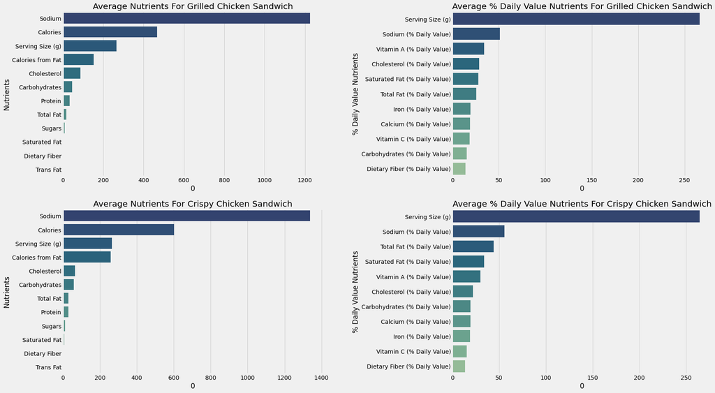

```python
# create a grid of subplots with 1 row and 2 columns
fig, axes = plt.subplots(nrows=2, ncols=2, figsize=(25, 15))

# plot the first graph in the first subplot
sns.barplot(x = 0, y = 'index', data = grill, ax=axes[0,0], palette='crest_r')
axes[0,0].set_title("Average Nutrients For Grilled Chicken Sandwich")
axes[0,0].set_ylabel('Nutrients')

# plot the second graph in the second subplot
sns.barplot(x = 0, y = 'index', data = grill1, ax=axes[0,1], palette='crest_r')
axes[0,1].set_title("Average % Daily Value Nutrients For Grilled Chicken Sandwich")
axes[0,1].set_ylabel('% Daily Value Nutrients')

# plot the third graph in the third subplot
sns.barplot(x = 0, y = 'index', data = crispy, ax=axes[1,0], palette='crest_r')
axes[1,0].set_title("Average Nutrients For Crispy Chicken Sandwich")
axes[1,0].set_ylabel('Nutrients')

# plot the fourth graph in the fourth subplot
sns.barplot(x = 0, y = 'index', data = crispy1, ax=axes[1,1], palette='crest_r')
axes[1,1].set_title("Average % Daily Value Nutrients For Crispy Chicken Sandwich")
axes[1,1].set_ylabel('% Daily Value Nutrients')


# adjust the spacing between subplots and display the plot
plt.subplots_adjust(wspace=0.5)
plt.show()
```

- Observation -
  - Aside from cholesterol and protein which is higher in grilled chicken sandwiches, crispy chicken sandwiches increases a sandwiches nutritional value more.
  - Sodium is really high in both grilled and crispy chicken sandwiches.
  - % Daily value for Total fat, Sat. fat, Sodium and carbohydrates are higher in crispy chicken sandwiches.
  - % Daily value for cholesterol, Dietary fiber, Vitamin A & C and Iron are higher in grilled chicken sandwiches.

### If ordering egg whites instead of whole eggs increases nutritional value?

###### For Eggs

```python
# creates a dataframe from mac2 and mac3 to hold values where category is breakfast and item contains egg only
eggdf = mac2[mac['Category'] == 'Breakfast'][mac['Item'].str.contains('egg', case=False)]
eggdf1 = mac3[mac['Category'] == 'Breakfast'][mac['Item'].str.contains('egg', case=False)]

# Check for where category is Breakfast and where item contains 'egg' for Nutrients
egg = eggdf[eggdf['Category'] == 'Breakfast'][~eggdf['Item'].str.contains('egg white', case=False) & eggdf['Item'].str.contains('egg', case=False)].mean().sort_values(ascending = False).reset_index()

# Check for where category is Breakfast and where item contains 'egg' for %Daily value
egg1 = eggdf1[eggdf1['Category'] == 'Breakfast'][~eggdf1['Item'].str.contains('egg white', case=False) & eggdf1['Item'].str.contains('egg', case=False)].mean().sort_values(ascending = False).reset_index()
```

###### For Egg Whites

```python
# Check for where category is Breakfast and where item contains 'egg whites' for Nutrients
eggw = eggdf[eggdf['Category'] == 'Breakfast'][mac['Item'].str.contains('egg white', case=False)].mean().sort_values(ascending = False).reset_index()

# Check for where category is Breakfast and where item contains 'egg whites' for %Daily value
eggw1 = eggdf1[eggdf1['Category'] == 'Breakfast'][mac['Item'].str.contains('egg white', case=False)].mean().sort_values(ascending = False).reset_index()
```

##### Plotting the Graph to compare between Egg and Egg Whites

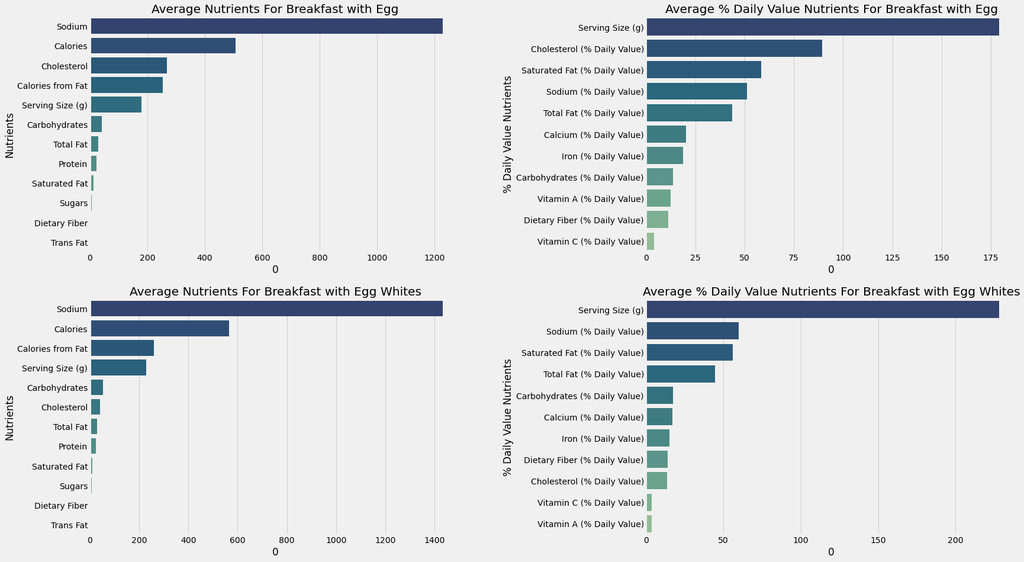

```python
# create a grid of subplots with 1 row and 2 columns
fig, axes = plt.subplots(nrows=2, ncols=2, figsize=(25, 15))

# plot the first graph in the first subplot
sns.barplot(x = 0, y = 'index', data = egg, ax=axes[0,0], palette='crest_r')
axes[0,0].set_title("Average Nutrients For Breakfast with Egg")
axes[0,0].set_ylabel('Nutrients')

# plot the second graph in the second subplot
sns.barplot(x = 0, y = 'index', data = egg1, ax=axes[0,1], palette='crest_r')
axes[0,1].set_title("Average % Daily Value Nutrients For Breakfast with Egg")
axes[0,1].set_ylabel('% Daily Value Nutrients')

# plot the third graph in the third subplot
sns.barplot(x = 0, y = 'index', data = eggw, ax=axes[1,0], palette='crest_r')
axes[1,0].set_title("Average Nutrients For Breakfast with Egg Whites")
axes[1,0].set_ylabel('Nutrients')

# plot the fourth graph in the fourth subplot
sns.barplot(x = 0, y = 'index', data = eggw1, ax=axes[1,1], palette='crest_r')
axes[1,1].set_title("Average % Daily Value Nutrients For Breakfast with Egg Whites")
axes[1,1].set_ylabel('% Daily Value Nutrients')


# adjust the spacing between subplots and display the plot
plt.subplots_adjust(wspace=0.5)
plt.show()
```

- Observation -
  - Aside for higher Cholesterol in Egg alone, Nutritional value increases when Breakfast is taken with Egg whites.
  - Sodium is really high in both Eggs and Egg Whites.
  - % Daily value for Cholesterol, Sat. Fat, Vitamin A & C, Calcium and Iron are higher in Eggs.
  - % Daily value for Sodium, Total Fat, Carbohydrate and Dietary fiber are higher in Egg whites.

### Finally

#### What is the Correlation between the Nutrients?

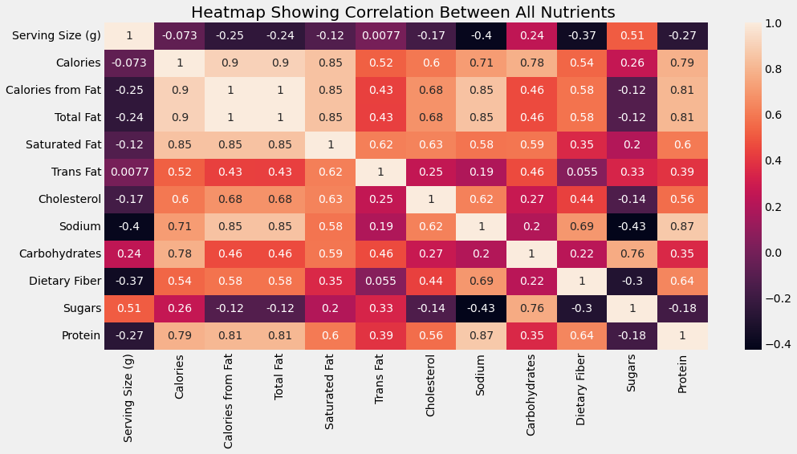

```python
# Set size of heatmap
plt.figure(figsize=(15,7))

# plot the correlation between all Nutrients
sns.heatmap(mac2.corr(),annot=True)
plt.title('Heatmap Showing Correlation Between All Nutrients ') # label the graph
```

#### Observation -

```
* Calories, Calories from fat, total fat, saturated fat are all highly correlated.
```

### Interactive Graph that changes when the appropriate items are selected

#### Aim

```
* To create outputs and visuals which can be easily used to sort through the data in the dataset.
* Can select any category and get items from that category and visualize according to the nutrient amount.
* Can compare different food items nutrients and % daily value.
* Can comapare nutrients amount per category.
```

```python
### create a function to get unique values from columnns, sort them and pass to a list ###

# creates variable called 'All'
All = 'All'

# create the function
def unique_sorted(array):
    """sorts, gets unique values and pass to list"""
    unique = array.sort_values().unique().tolist() # sorts, gets unique values and pass to list
    unique.insert(0, All) # inserts sorted unique list to All variable
    return unique # return the unique values
```

```python
# variables to be used for dropdowns

# variable to be use to pass as dropdown and sort outputs
nutrient = ['All','Calories', 'Calories from Fat', 'Total Fat', 'Saturated Fat', 'Trans Fat', 'Cholesterol', 'Sodium',
                 'Carbohydrates', 'Dietary Fiber', 'Sugars', 'Protein']

# variable to be use to pass as dropdown and sort outputs
daily_value = ['All','Total Fat (% Daily Value)', 'Saturated Fat (% Daily Value)', 'Cholesterol (% Daily Value)',
                'Sodium (% Daily Value)', 'Carbohydrates (% Daily Value)','Dietary Fiber (% Daily Value)',
                'Vitamin A (% Daily Value)','Vitamin C (% Daily Value)', 'Calcium (% Daily Value)','Iron (% Daily Value)']

# variable to be use to pass as dropdown and sort outputs
mix = ['All', 'Calories', 'Calories from Fat', 'Total Fat', 'Saturated Fat', 'Trans Fat', 'Cholesterol', 'Sodium',
        'Carbohydrates', 'Dietary Fiber', 'Sugars', 'Protein','Total Fat (% Daily Value)', 'Saturated Fat (% Daily Value)', 'Cholesterol (% Daily Value)',
        'Sodium (% Daily Value)', 'Carbohydrates (% Daily Value)','Dietary Fiber (% Daily Value)',
        'Vitamin A (% Daily Value)','Vitamin C (% Daily Value)', 'Calcium (% Daily Value)','Iron (% Daily Value)',
        'Compare Nutrients','Compare % Daily value']

# variable to be use to pass as dropdown and sort outputs
mac4 = mac[['Category','Item','Calories', 'Calories from Fat', 'Total Fat', 'Saturated Fat', 'Trans Fat',
            'Cholesterol','Carbohydrates', 'Dietary Fiber', 'Sugars', 'Protein']]

# variable to be use to pass as dropdown and sort outputs
mac5 = mac[['Category','Item','Total Fat (% Daily Value)','Saturated Fat (% Daily Value)', 'Cholesterol (% Daily Value)',
            'Sodium (% Daily Value)','Carbohydrates (% Daily Value)', 'Dietary Fiber (% Daily Value)',
            'Vitamin A (% Daily Value)','Vitamin C (% Daily Value)','Calcium (% Daily Value)', 'Iron (% Daily Value)']]
```

```python
# Use ipywidgets to create the drop downs
import ipywidgets as widgets
```

```python
# Main

### create a function using ipywidgets dropdowns to plot bar graphs depending on the selected item ###

nutrients_output = widgets.Output() # ouput of the widgets to be displayed
nutrients_plot = widgets.Output() # ouput of the selected graph to be displayed


#-------------------------------create variables to be passed into dropdown widgets----------------------------#

sel_cat = widgets.Dropdown(options=unique_sorted(mac['Category']), description = 'Category')  # uses uniques_sorted funct. to get unique category
sel_item = widgets.Dropdown(options=unique_sorted(mac['Item']), description = 'Items') # uses uniques_sorted funct. to get unique items
sel_size = widgets.IntSlider(min = 0, max = 1000, step = 20, description = 'Serving Size', value = 1000) # creates a slider that filters output depending serving size
sel_nutrient = widgets.Dropdown(options = nutrient, description = 'Sort Nutrients')  # sorts and outputs nutrients for items in descending order
sel_value = widgets.Dropdown(options = daily_value, description = 'Sort % Daily Value')  # sorts and outputs % daily values for items in descending order

sel_plot = widgets.Dropdown(options = mix, description='Plot') # passes the columns to plot as options


#--------------------create function to get unique items when a category is selected----------------------#

def get_items_in_category(category):

    if category == 'All':
        # if category == All, return all unique items
        return unique_sorted(mac['Item'])
    else:
        # elif a unique category is selected, return unique items for category
        return unique_sorted(mac[mac['Category'] == category]['Item'])

#--------------------create function to sort items when a nutrient is selected----------------------#

def sort_by(df,value):
    if value in df.columns:
        return df.sort_values(by = value, ascending = False)

#----------------create function to get dropdown values and filter outputs as values are changed--------------#

def category_filtering(category, item, size, nutrient, value, plot):
    nutrients_output.clear_output() # clears the ouput of the selected items when a new one is selected
    nutrients_plot.clear_output() # clears the ouput of the selected graph when a new one is selected

    #------------------------Filter For selected category---------------------------#

    if category == 'All':
        category_filter = mac # if category = All, category filter = mac dataframe
        item_options = get_items_in_category('All') # item_options updates to unique items for that category
    else:
        category_filter = mac[mac['Category'] == category]  # elif a unique category is selected, return unique items
        item_options = get_items_in_category(category)  # item_options updates to unique items for that category
    sel_item.options = item_options # then passes item_options as options for sel_item variable

    #------------------------Filter For size slider ---------------------------#

    if (category != 'All') & (size == sel_size.value):
        category_filter = mac[(mac['Category'] == category)
                              & (mac['Serving Size (g)'] <= size)].sort_values(by = 'Serving Size (g)', ascending = False)

    if (category == 'All') & (item == 'All') & (size == sel_size.value):
        category_filter = mac[(mac['Serving Size (g)'] <= size)].sort_values(by = 'Serving Size (g)', ascending = False)

    #------------------------Filter For selected item type---------------------------#

    if item == 'All':
        pass # do nothing
    else:
        category_filter = mac[(mac['Category'] == category) & (mac['Item'] == item)] # else All category & items

    #-------------------Filter For selected nutrient type---------------------#

    if nutrient == 'All':
        pass # do nothing
    elif nutrient == sel_nutrient.value: # if a nutrient is selected
        sort_filter = sort_by(mac2, sel_nutrient.value) # sort by nutrient in dataframe(mac2)
        category_filter = sort_filter[sort_filter['Category'] == category] # output

    # if a category & value is All & nutrient is selected, sort by nutrient in dataframe(mac2)
    if (category == 'All') & (nutrient == sel_nutrient.value) & (value == 'All'):
        category_filter = sort_by(mac2, sel_nutrient.value) # output

    #--------------------Filter For selected % daily value type--------------------#

    if value == 'All':
        pass # do nothing
    elif value == sel_value.value: # if a value is selected
        sort_filter = sort_by(mac3, sel_value.value) # sort by value in dataframe(mac3)
        category_filter = sort_filter[sort_filter['Category'] == category] # output

    # if a category & value is selected & nutrient is All, sort by nutrient in dataframe(mac2)
    if (category == 'All') & (value == sel_value.value) & (nutrient == 'All'):
        category_filter = sort_by(mac3, sel_value.value)   # output

    #------------------------For outputs---------------------------#

    with nutrients_output:
        print('There are', len(category_filter), 'Items in this category' ) # prints output details
        display(category_filter) # displays Output

    with nutrients_plot:
        plt.figure(figsize=(15,10)) # set figure size for graph
        global compare_filter # makes variable a global one

        if (plot == 'All'):
            pass # do nothing

        elif (category != 'All') & (item != 'All') & (plot == 'Compare Nutrients'):
            compare_filter = mac4[(mac4['Category'] == category) & (mac4['Item'] == item)]

            print('This Shows Nutrient Stats For ', item) # prints graph details
            print('Sodium isn\'t included due to its ridiculuous high amount in Food Items on the menu ') # prints graph details

            # ---- plot a pointplot chart ---- #
            sns.pointplot(data = compare_filter, color = 'r' ) # Gets output from category_filter variable
            plt.xticks(rotation = 90, fontsize = 15) # set x axis ticks format
            plt.xlabel('Nutrients', fontsize = 15) # set x axis label
            plt.yticks(fontsize = 15) # set y axis ticks format
```

```python
            # --- To edit the Legend --- #
            legend_labels = [item] # set legend to values in item
            handles = [plt.Line2D([], [], color = 'r', marker = '.', markersize = 10, linewidth = 2)]
            plt.legend(handles = handles, labels = legend_labels, loc = 1 , fontsize = 20)

            plt.grid() # type of plot
            plt.show()

        elif (category != 'All') & (item != 'All') & (plot == 'Compare % Daily value'):
            compare_filter = mac5[(mac5['Category'] == category) & (mac5['Item'] == item)]

            print('This Shows % Daily value Stats For ', item) # prints graph details
            # ---- plot a pointplot chart ---- #
            sns.pointplot(data = compare_filter, color = 'g' ) # Gets output from category_filter variable
            plt.xticks(rotation = 90, fontsize = 15) # set x axis ticks format
            plt.xlabel('Nutrients', fontsize = 15) # set x axis label
            plt.yticks(fontsize = 15) # set y axis ticks format
            plt.grid() # type of plot

            # --- To edit the Legend --- #
            legend_labels = [item] # set legend to values in item
            handles = [plt.Line2D([], [], color = 'g', marker = '.', markersize = 10, linewidth = 2)]
            plt.legend(handles = handles, labels = legend_labels, loc = 1 , fontsize = 20)

            plt.show()

        elif plot == sel_plot.value:
            category_filter = category_filter.reset_index()

            # prints graph details
            print('This Shows Nutrients For Food items', category, 'With Serving Size(g) in front of the bars')

            # Set up the plot
            fig, ax = plt.subplots(figsize=(15, 10))
            sns.barplot(x = category_filter[sel_plot.value], y = category_filter['Item'][:42], palette = 'crest_r', ax=ax)

            # Add the serving sizes as text labels in front of the bars
            for i, v in enumerate(category_filter[sel_plot.value][:42]):
                ax.text(v + 3, i , str(category_filter['Serving Size (g)'][i]), color='black', fontweight='bold')

            # Set the plot title and axis labels
            ax.set_title('Bar Plot with Serving Size (g) Labels')
            ax.set_xlabel(sel_plot.value)
            plt.show()

#--------------------create functions to observe when a change is made for each dropdown---------------------#

def category_sel(change): # observes when category is changed and selects values for other dropdowns for that club
    category_filtering(change.new, sel_item.value, sel_size.value, sel_nutrient.value, sel_value.value, sel_plot.value)

def item_sel(change): # observes when item is changed and selects values for other dropdowns for that type
    category_filtering(sel_cat.value, change.new, sel_size.value, sel_nutrient.value, sel_value.value, sel_plot.value)

def size_sel(change): # observes when size is changed and selects values for other dropdowns for that type
    category_filtering(sel_cat.value, sel_item.value, change.new, sel_nutrient.value, sel_value.value, sel_plot.value)

def nutrient_sel(change): # observes when nutrient is changed and selects values for other dropdowns for that type
    category_filtering(sel_cat.value, sel_item.value, sel_size.value, change.new, sel_value.value, sel_plot.value)

def value_sel(change): # observes when value is changed and selects values for other dropdowns for that type
    category_filtering(sel_cat.value, sel_item.value, sel_size.value, sel_nutrient.value, change.new, sel_plot.value)

def plot_sel(change): # observes when plot is changed and selects values for other dropdowns for that type
    category_filtering(sel_cat.value, sel_item.value, sel_size.value, sel_nutrient.value, sel_value.value, change.new)


#---------------------- observes the function and selects appropriate values------------------#

sel_cat.observe(category_sel, names = 'value') # observes category selection
sel_item.observe(item_sel, names = 'value') # observes item selection
sel_size.observe(size_sel, names = 'value') # observes size filtering selection
sel_nutrient.observe(nutrient_sel, names = 'value') # observes nutrient selection
sel_value.observe(value_sel, names = 'value') # observes value selection
sel_plot.observe(plot_sel, names = 'value') # observes plot selection

sel_size.disabled = True # disables sel_size on default
sel_nutrient.disabled = True # disables sel_nutrient on default
sel_value.disabled = True # disables sel_value on default

def enable_sel_nutrient_and_value(change):
    if (change.new == 'All'):
        sel_nutrient.disabled = False # enables dropdowns if item is All
        sel_value.disabled = False # enables dropdowns if item is All
    else:
        sel_nutrient.disabled = True # disables dropdowns when item is selected
        sel_value.disabled = True # disables dropdowns when unique item is selected

sel_item.observe(enable_sel_nutrient_and_value, names='value') # observes enable_sel_nutrient.. for changes

def enable_sel_value(change):
    if (change.new == 'All'):
        sel_value.disabled = False # enables sel_value when nutrient is All
    else:
        sel_value.disabled = True # disables sel_value when unique nutrient is selected

sel_nutrient.observe(enable_sel_value, names='value') # observes enable_sel_nutrient.. for changes

def enable_sel_size(change):
    if (change.new == 'All'):
        sel_size.disabled = False # enables sel_size when other dropdowns is All
    else:
        sel_size.disabled = True # disables sel_size when dropdown values change from All

sel_item.observe(enable_sel_size, names='value') # observes enable_sel_size for changes
sel_nutrient.observe(enable_sel_size, names='value') # observes enable_sel_size for changes
sel_value.observe(enable_sel_size, names='value') # observes enable_sel_size for changes
sel_plot.observe(enable_sel_size, names='value') # observes enable_sel_size for changes

#---------------------- arranges dropdowns in horizontal form --------------#

input_widget = widgets.HBox([sel_cat, sel_item, sel_size])
input_widget2 = widgets.HBox([sel_nutrient, sel_value, sel_plot])
```

#### About Data Exploration & Visuals:

```
* With this Dashboards you can select a Food category.
* With the category selected, you can select a Food item in that category, to view nutrient or % Daily value stats      individually.
* With a category selected, you can sort with the Serving size slider. When other dropdowns are set to All, aside that  Serving size slider is normally disabled.
* After selecting a Category, you can either sort by Nutrients or % Daily value (but not both) to sort the output from  in descending order according to the Nutrient or % Daily value selected.
* View your data by selecting the Plots tab.
```

#### Notes For Dashboard use:

```
* Select Category.
* Sort by Serving size - `slider only activates when a category is selected & other dropdowns are set to All.
* Sort by Nutreints when a Category is selected, to view the output in descending order by Nutrient selected
(Sort % Daily value must be set to All if activated).
* Sort by % Daily value when a Category is selected, to view the output in descending order by value selected
(Sort Nutrients must be set to All if activated).
* After Sorting, view plots in Plot tab by either Nutrients or % Daily value.
```

### Dashboard 1 - General and Individual Food Item use

```python
# display dropdowns and plot graph

tab = widgets.Tab([nutrients_output, nutrients_plot]) # create two tabs for exploration and chart
tab.set_title(0, 'Data Exploration')
tab.set_title(1, 'Plots')

dashboard = widgets.VBox([input_widget, input_widget2, tab]) # creates dashboard with dropdown inputs and tabs
display(dashboard) # display dashboard
```

```
VBox(children=(HBox(children=(Dropdown(description='Category', options=('All', 'Beef & Pork', 'Beverages', 'Br…
```

#### * Note: Select a Food item you will like to compare with another by:

```
        * Select Category.
        * Select Food Item for that Category.
        * Select Compare Nutrients or Compare % Daily Value in Plot dropdown.
        * Go to Dashboard 2 and do the same process to compare 2 Food items.
```

```python
# Main2 -  to compare Food item from main with food item from Main 2

### create a function using ipywidgets dropdowns to plot bar graphs depending on the selected item ###

nutrients_output2 = widgets.Output() # ouput of the widgets to be displayed
nutrients_plot2 = widgets.Output() # ouput of the selected graph to be displayed
item_compare = widgets.Output() # ouput of the selected graph to be displayed

mix2 = ['Nutrients', '% Daily value'] # variable to be passed as dropdowns
compare = ['Compare Nutrients', 'Compare % Daily value'] # variable to be passed as dropdowns

#-------------------------------create variables to be passed into dropdown widgets----------------------------#

sel_cat2 = widgets.Dropdown(options=unique_sorted(mac['Category']), description = 'Category 2')  # uses uniques_sorted funct. to get unique category
sel_item2 = widgets.Dropdown(options=unique_sorted(mac['Item']), description = 'Items 2') # uses uniques_sorted funct. to get unique items
sel_plot2 = widgets.Dropdown(options = mix2, description='Plot 2') # passes the columns to plot as options
plot_compare = widgets.Dropdown(options = compare, description='Compare Items') # passes the columns to plot as options

#--------------------create function to get unique items when a category is selected----------------------#

def get_items_in_category2(category2):

    if category2 == 'All':
        # if category == All, return all unique items
        return unique_sorted(mac['Item'])
    else:
        # elif a unique category is selected, return unique items for category
        return unique_sorted(mac[mac['Category'] == category2]['Item'])


#----------------create function to get dropdown values and filter outputs as values are changed--------------#

def category_filtering2(category2, item2, plot2, compare):
    nutrients_output2.clear_output() # clears the ouput of the selected items when a new one is selected
    nutrients_plot2.clear_output() # clears the ouput of the selected graph when a new one is selected
    item_compare.clear_output() # clears the ouput of the selected graph variables when a new one is selected

    global compare_filter2 # makes varibale a global one

    #------------------------Filter For selected category---------------------------#

    if category2 == 'All':
        category_filter2 = mac # if category2 = All, category_filter2 = mac dataframe
        item_options2 = get_items_in_category2('All') # item_options2 updates to unique items for that category
    else:
        category_filter2 = mac[mac['Category'] == category2]  # elif a unique category is selected, return unique items
        item_options2 = get_items_in_category2(category2)  # item_options2 updates to unique items for that category
    sel_item2.options = item_options2 # then passes item_options2 as options for sel_item2 variable


    #------------------------Filter For selected item type---------------------------#

    if item2 == 'All':
        pass # do nothing
    else:
        category_filter2 = mac[(mac['Category'] == category2) & (mac['Item'] == item2)] # else All category & items

    #------------------------For outputs---------------------------#

    with nutrients_output2:
        print('There are', len(category_filter2), 'Items in this category') # prints output details
        display(category_filter2) # displays Output

    with nutrients_plot2:
        plt.figure(figsize=(15,10)) # set figure size for graph

        if (plot2 == 'All'):
            pass # do nothing

        elif (category2 != 'All') & (item2 != 'All') & (plot2 == 'Nutrients'):
            compare_filter2 = mac4[(mac4['Category'] == category2) & (mac4['Item'] == item2)]

            print('This Shows Nutrient Stats For ', item2) # prints graph details
            print('Sodium isn\'t included due to its ridiculuous high amount in Food Items on the menu ') # prints graph details

            # ---- plot a pointplot chart ---- #
            sns.pointplot(data = compare_filter2, color = 'b' ) # Gets output from compare_filter variable
            plt.xticks(rotation = 90, fontsize = 15) # set x axis ticks format
            plt.xlabel('Nutrients', fontsize = 15) # set x axis label
            plt.yticks(fontsize = 15) # set y axis ticks format
            plt.grid() # type of plot

            # --- To edit the Legend --- #
            legend_labels = [item2] # set legend to values in item2
            handles = [plt.Line2D([], [], color = 'b', marker = '.', markersize = 10, linewidth = 2)]
            plt.legend(handles = handles, labels = legend_labels, loc = 1 , fontsize = 20)

            plt.show()

        elif (category2 != 'All') & (item2 != 'All') & (plot2 == '% Daily value'):
            compare_filter2 = mac5[(mac5['Category'] == category2) & (mac5['Item'] == item2)]

            print('This Shows % Daily value Stats For ', item2) # prints graph details
            # ---- plot a pointplot chart ---- #
            sns.pointplot(data = compare_filter2, color = 'y' ) # Gets output from category_filter variable
            plt.xticks(rotation = 90, fontsize = 15) # set x axis ticks format
            plt.xlabel('Nutrients', fontsize = 15) # set x axis label
            plt.yticks(fontsize = 15) # set y axis ticks format
            plt.grid() # type of plot

            # --- To edit the Legend --- #
            legend_labels = [item2] # set legend to values in item2
            handles = [plt.Line2D([], [], color = 'y', marker = '.', markersize = 10, linewidth = 2)]
            plt.legend(handles = handles, labels = legend_labels, loc = 1 , fontsize = 20)

            plt.show()

    with item_compare:
        plt.figure(figsize=(15,10)) # set figure size for graph

        # if plot2(compare) is set to Compare
        if (compare == 'Compare Nutrients') & (category2 != 'All') & (item2 != 'All'):
            plt.figure(figsize = (15,10))

            # ---- plot a pointplot chart to compare both Food items ---- #
            sns.pointplot(data = compare_filter, color = 'r') # get data for Food item 1 from compare_filter variable
            sns.pointplot(data = compare_filter2, color = 'b') # get data for Food item 2 from compare_filter2 variable
            print('Nutrient Stats Comparison of', compare_filter['Item'].values, 'from', compare_filter['Category'].values,
                  ' category and', item2,'from',category2,'category', '\n','\n') # print graph details
            print('Comparing a', compare_filter['Category'].values, 'item, with a',
                  compare_filter2['Category'].values, 'item') # print graph details
            plt.title('Comparing Both Food Nutrients', fontsize = 15) # set title
            plt.xticks(rotation = 90, fontsize = 15) # set x axis ticks format
            plt.xlabel('Nutrients', fontsize = 15) # set y axis label
            plt.yticks(fontsize = 15) # set y axis ticks format
            plt.grid() # type of plot

            # ---- add legend with colors for each food items ---- #
            legend_labels = [compare_filter['Item'].values , item2] # set legend to values in item & item2
            handles = [plt.Line2D([], [], color = 'r', marker = '.', markersize = 10, linewidth = 2),
                       plt.Line2D([], [], color = 'b', marker = '.', markersize = 10, linewidth = 2)]
            plt.legend(handles = handles, labels = legend_labels, loc = 1 , fontsize = 20)

            plt.show() # show plot

        elif (compare == 'Compare % Daily value') & (category2 != 'All') & (item2 != 'All'):
            plt.figure(figsize = (15,10))

            # ---- plot a pointplot chart to compare both Food items ---- #
            sns.pointplot(data = compare_filter, color = 'g') # get data for Food item 1 from compare_filter variable
            sns.pointplot(data = compare_filter2, color = 'y') # get data for Food item 2 from compare_filter2 variable
            print('% Daily Value Stats Comparison of', compare_filter['Item'].values, 'from', compare_filter['Category'].values,
                  'category and', item2,'from',category2, 'category','\n','\n') # print graph details
            print('Comparing a', compare_filter['Category'].values, 'item, with a',
                  compare_filter2['Category'].values, 'item') # print graph details
            plt.title('Comparing Both Food % Daily Value', fontsize = 15) # set title
            plt.xticks(rotation = 90, fontsize = 15) # set x axis ticks format
            plt.xlabel('Nutrients', fontsize = 15) # set y axis label
            plt.yticks(fontsize = 15) # set y axis ticks format
            plt.grid() # type of plot

            # ---- add legend with colors for each food item ---- #
            legend_labels = [compare_filter['Item'].values , item2] # set legend to values in item & item2
            handles = [plt.Line2D([], [], color = 'g', marker = '.', markersize = 10, linewidth = 2),
                       plt.Line2D([], [], color = 'y', marker = '.', markersize = 10, linewidth = 2)]
            plt.legend(handles = handles, labels = legend_labels, loc = 1 , fontsize = 20)

            plt.show() # show plot

#--------------------create functions to observe when a change is made for each dropdown---------------------#

def category_sel2(change): # observes when category is changed and selects values for other dropdowns for that club
    category_filtering2(change.new, sel_item2.value, sel_plot2.value, plot_compare.value)

def item_sel2(change): # observes when item is changed and selects values for other dropdowns for that type
    category_filtering2(sel_cat2.value, change.new, sel_plot2.value, plot_compare.value)

def plot_sel2(change): # observes when plot is changed and selects values for other dropdowns for that type
    category_filtering2(sel_cat2.value, sel_item2.value, change.new, plot_compare.value)

def compare_plots(change): # observes when compare plot is changed and selects values for other dropdowns for that type
    category_filtering2(sel_cat2.value, sel_item2.value, sel_plot2.value, change.new)


#---------------------- observes the function and selects appropriate values------------------#

sel_cat2.observe(category_sel2, names = 'value') # observes category selection
sel_item2.observe(item_sel2, names = 'value') # observes item selection
sel_plot2.observe(plot_sel2, names = 'value') # observes value selection
plot_compare.observe(compare_plots, names = 'value') # observes compare plot selection

#---------------------- arranges dropdowns in horizontal form --------------#

input_widget3 = widgets.HBox([sel_cat2, sel_item2, sel_plot2])
input_widget4 = widgets.HBox([plot_compare])
```

### Dashboard 2 - For Food Item 2, used to compare stats with selected Food item in Dashboard 1

- Note: This Dashboard is used to compare single Food item from Dashboard 1 with selected Food item in Dashboard 2

```python
# display dropdowns and plot graph

tab2 = widgets.Tab([nutrients_output2, nutrients_plot2, item_compare]) # create five tabs for exploration and chart
tab2.set_title(0, 'Data Exploration2')
tab2.set_title(1, 'Plots2')
tab2.set_title(2, 'Compare')

dashboard2 = widgets.VBox([input_widget3, input_widget4, tab2]) # creates dashboard with dropdown inputs and tabs
display(dashboard2) # display dashboard
```

```
VBox(children=(HBox(children=(Dropdown(description='Category 2', options=('All', 'Beef & Pork', 'Beverages', '…
```